# Ford GoBike System Data Exploration

## Introduction

> The ford gobike system dataset includes information about individual rides made in a bike-sharing system covering the greater San Francisco Bay area.

### QUESTION(S) FOR ANALYSIS

- What is the proportion of the gender among the users?
- What is the proportion of user type among the users?
- What's the bike sharing behaviour among the users?
- How is the age of the users distributed in the dataset?
- At what hour do users mostly start their trip?
- Which of the days do users use bikes the most?
- Which of the month do users mostly use bike the most?
- How long do users go for their trips?
- What stations are used most?
- How often do users take trips in the month?
- What is the average distance taken by age group?
- What is the average distance taken by User type?
- What's the trip distance by age group and User type?
- What's the average duration and distance of trips by Gender, User type and Age group?

```python
# importing all neccessary packages and setting plots to be embedded inline

import numpy as np
import pandas as pd
import matplotlib.pyplot as plt
import seaborn as sns
from pandas.api.types import CategoricalDtype

# For the geopy Library
!pip install geopy
from geopy import distance


%matplotlib inline
```

```
    100% |████████████████████████████████| 122kB 4.7MB/s ta 0:00:01
```

```python
# Loading the dataset into my jupyter notebook

df = pd.read_csv('201902-fordgobike-tripdata.csv')
```

### DATA ASSESSMENT

> In this section, I will assess the dataset and check if there are any data issues

```python
# Having an overview of the dataset

df.head(10)
```

|  | duration_sec | start_time | end_time | start_station_id | start_station_name | start_station_latitude | start_station_longitude | end_station_id | end_station_name | end_station_latitude | end_station_longitude | bike_id | user_type | member_birth_year | member_gender | bike_share_for_all_trip |
| --- | --- | --- | --- | --- | --- | --- | --- | --- | --- | --- | --- | --- | --- | --- | --- | --- |
| 0 | 52185 | 2019-02-28 17:32:10.1450 | 2019-03-01 08:01:55.9750 | 21.0 | Montgomery St BART Station (Market St at 2nd St) | 37.789625 | -122.400811 | 13.0 | Commercial St at Montgomery St | 37.794231 | -122.402923 | 4902 | Customer | 1984.0 | Male | No |
| 1 | 42521 | 2019-02-28 18:53:21.7890 | 2019-03-01 06:42:03.0560 | 23.0 | The Embarcadero at Steuart St | 37.791464 | -122.391034 | 81.0 | Berry St at 4th St | 37.775880 | -122.393170 | 2535 | Customer | NaN | NaN | No |
| 2 | 61854 | 2019-02-28 12:13:13.2180 | 2019-03-01 05:24:08.1460 | 86.0 | Market St at Dolores St | 37.769305 | -122.426826 | 3.0 | Powell St BART Station (Market St at 4th St) | 37.786375 | -122.404904 | 5905 | Customer | 1972.0 | Male | No |
| 3 | 36490 | 2019-02-28 17:54:26.0100 | 2019-03-01 04:02:36.8420 | 375.0 | Grove St at Masonic Ave | 37.774836 | -122.446546 | 70.0 | Central Ave at Fell St | 37.773311 | -122.444293 | 6638 | Subscriber | 1989.0 | Other | No |
| 4 | 1585 | 2019-02-28 23:54:18.5490 | 2019-03-01 00:20:44.0740 | 7.0 | Frank H Ogawa Plaza | 37.804562 | -122.271738 | 222.0 | 10th Ave at E 15th St | 37.792714 | -122.248780 | 4898 | Subscriber | 1974.0 | Male | Yes |
| 5 | 1793 | 2019-02-28 23:49:58.6320 | 2019-03-01 00:19:51.7600 | 93.0 | 4th St at Mission Bay Blvd S | 37.770407 | -122.391198 | 323.0 | Broadway at Kearny | 37.798014 | -122.405950 | 5200 | Subscriber | 1959.0 | Male | No |
| 6 | 1147 | 2019-02-28 23:55:35.1040 | 2019-03-01 00:14:42.5880 | 300.0 | Palm St at Willow St | 37.317298 | -121.884995 | 312.0 | San Jose Diridon Station | 37.329732 | -121.901782 | 3803 | Subscriber | 1983.0 | Female | No |
| 7 | 1615 | 2019-02-28 23:41:06.7660 | 2019-03-01 00:08:02.7560 | 10.0 | Washington St at Kearny St | 37.795393 | -122.404770 | 127.0 | Valencia St at 21st St | 37.756708 | -122.421025 | 6329 | Subscriber | 1989.0 | Male | No |
| 8 | 1570 | 2019-02-28 23:41:48.7900 | 2019-03-01 00:07:59.7150 | 10.0 | Washington St at Kearny St | 37.795393 | -122.404770 | 127.0 | Valencia St at 21st St | 37.756708 | -122.421025 | 6548 | Subscriber | 1988.0 | Other | No |
| 9 | 1049 | 2019-02-28 23:49:47.6990 | 2019-03-01 00:07:17.0250 | 19.0 | Post St at Kearny St | 37.788975 | -122.403452 | 121.0 | Mission Playground | 37.759210 | -122.421339 | 6488 | Subscriber | 1992.0 | Male | No |

```python
# Getting the shape of the dataset ie. the number of rows and column

df.shape
```

```
(183412, 16)
```

```python
# Getting information about each column of the dataset.

df.info()
```

```
<class 'pandas.core.frame.DataFrame'>
RangeIndex: 183412 entries, 0 to 183411
Data columns (total 16 columns):
duration_sec               183412 non-null int64
start_time                 183412 non-null object
end_time                   183412 non-null object
start_station_id           183215 non-null float64
start_station_name         183215 non-null object
start_station_latitude     183412 non-null float64
start_station_longitude    183412 non-null float64
end_station_id             183215 non-null float64
end_station_name           183215 non-null object
end_station_latitude       183412 non-null float64
end_station_longitude      183412 non-null float64
bike_id                    183412 non-null int64
user_type                  183412 non-null object
member_birth_year          175147 non-null float64
member_gender              175147 non-null object
bike_share_for_all_trip    183412 non-null object
dtypes: float64(7), int64(2), object(7)
memory usage: 22.4+ MB
```

```python
#Checking for rows with empty entries

df.isnull().sum()
```

```
duration_sec                  0
start_time                    0
end_time                      0
start_station_id            197
start_station_name          197
start_station_latitude        0
start_station_longitude       0
end_station_id              197
end_station_name            197
end_station_latitude          0
end_station_longitude         0
bike_id                       0
user_type                     0
member_birth_year          8265
member_gender              8265
bike_share_for_all_trip       0
dtype: int64
```

> The following columns include empty entries: start_station_id ,start_station_name , end_station_id, end_station_name, member_birth_year, member_gender.

```python
# Checking for duplicated rows

df.duplicated().sum()
```

```
0
```

> There are no duplicated rows

```python
# Computing simple statistics for the dataset

df.describe()
```

|  | duration_sec | start_station_id | start_station_latitude | start_station_longitude | end_station_id | end_station_latitude | end_station_longitude | bike_id | member_birth_year |
| --- | --- | --- | --- | --- | --- | --- | --- | --- | --- |
| count | 183412.000000 | 183215.000000 | 183412.000000 | 183412.000000 | 183215.000000 | 183412.000000 | 183412.000000 | 183412.000000 | 175147.000000 |
| mean | 726.078435 | 138.590427 | 37.771223 | -122.352664 | 136.249123 | 37.771427 | -122.352250 | 4472.906375 | 1984.806437 |
| std | 1794.389780 | 111.778864 | 0.099581 | 0.117097 | 111.515131 | 0.099490 | 0.116673 | 1664.383394 | 10.116689 |
| min | 61.000000 | 3.000000 | 37.317298 | -122.453704 | 3.000000 | 37.317298 | -122.453704 | 11.000000 | 1878.000000 |
| 25% | 325.000000 | 47.000000 | 37.770083 | -122.412408 | 44.000000 | 37.770407 | -122.411726 | 3777.000000 | 1980.000000 |
| 50% | 514.000000 | 104.000000 | 37.780760 | -122.398285 | 100.000000 | 37.781010 | -122.398279 | 4958.000000 | 1987.000000 |
| 75% | 796.000000 | 239.000000 | 37.797280 | -122.286533 | 235.000000 | 37.797320 | -122.288045 | 5502.000000 | 1992.000000 |
| max | 85444.000000 | 398.000000 | 37.880222 | -121.874119 | 398.000000 | 37.880222 | -121.874119 | 6645.000000 | 2001.000000 |

```python
# Checking for unique values of each column

df.nunique()
```

```
duration_sec                 4752
start_time                 183401
end_time                   183397
start_station_id              329
start_station_name            329
start_station_latitude        334
start_station_longitude       335
end_station_id                329
end_station_name              329
end_station_latitude          335
end_station_longitude         335
bike_id                      4646
user_type                       2
member_birth_year              75
member_gender                   3
bike_share_for_all_trip         2
dtype: int64
```

## DATA QUALITY ISSUES

> Below are all the quality issues observed
- Null values in the following columns: start_station_id, start_station_name, end_station_id and end_station_name columns.
- Inappropiate member_birth_year values between 1878.0 and 1938.0 and nan values
- Incorrect datatypes for the following columns: start_time, end_time, start_station_id, end_station_id, bike_id, member_birth_year.

## DATA TIDINESS ISSUES

> Below are all the tideness issues observed
- There should be different columns for the following: start and end time, day and month columns.
- The member_birth_year should be the member's age not their birth year.
- The duration_sec should be in hours.
- Trip distance column should be calculated.

## DATA CLEANING

> In this section, I will clean the data in order to correct all the issues observed

```python
# Getting a copy of the dataset

df_copy = df.copy()
```

```python
# Having an overview of the copied data

df_copy.head()
```

|  | duration_sec | start_time | end_time | start_station_id | start_station_name | start_station_latitude | start_station_longitude | end_station_id | end_station_name | end_station_latitude | end_station_longitude | bike_id | user_type | member_birth_year | member_gender | bike_share_for_all_trip |
| --- | --- | --- | --- | --- | --- | --- | --- | --- | --- | --- | --- | --- | --- | --- | --- | --- |
| 0 | 52185 | 2019-02-28 17:32:10.1450 | 2019-03-01 08:01:55.9750 | 21.0 | Montgomery St BART Station (Market St at 2nd St) | 37.789625 | -122.400811 | 13.0 | Commercial St at Montgomery St | 37.794231 | -122.402923 | 4902 | Customer | 1984.0 | Male | No |
| 1 | 42521 | 2019-02-28 18:53:21.7890 | 2019-03-01 06:42:03.0560 | 23.0 | The Embarcadero at Steuart St | 37.791464 | -122.391034 | 81.0 | Berry St at 4th St | 37.775880 | -122.393170 | 2535 | Customer | NaN | NaN | No |
| 2 | 61854 | 2019-02-28 12:13:13.2180 | 2019-03-01 05:24:08.1460 | 86.0 | Market St at Dolores St | 37.769305 | -122.426826 | 3.0 | Powell St BART Station (Market St at 4th St) | 37.786375 | -122.404904 | 5905 | Customer | 1972.0 | Male | No |
| 3 | 36490 | 2019-02-28 17:54:26.0100 | 2019-03-01 04:02:36.8420 | 375.0 | Grove St at Masonic Ave | 37.774836 | -122.446546 | 70.0 | Central Ave at Fell St | 37.773311 | -122.444293 | 6638 | Subscriber | 1989.0 | Other | No |
| 4 | 1585 | 2019-02-28 23:54:18.5490 | 2019-03-01 00:20:44.0740 | 7.0 | Frank H Ogawa Plaza | 37.804562 | -122.271738 | 222.0 | 10th Ave at E 15th St | 37.792714 | -122.248780 | 4898 | Subscriber | 1974.0 | Male | Yes |

### Issue 1: Null values in the following columns: start_station_id, start_station_name, end_station_id and end_station_name columns.

### What to do: Drop null values in the affected columns: Drop null values in the affected columns

```python
# Dropping the null values

df_copy = df_copy.dropna(subset=['start_station_id', 'start_station_name','end_station_id','end_station_name'])
```

```python
# Checking if the null values were dropped

df_copy.isnull().sum()
```

```
duration_sec                  0
start_time                    0
end_time                      0
start_station_id              0
start_station_name            0
start_station_latitude        0
start_station_longitude       0
end_station_id                0
end_station_name              0
end_station_latitude          0
end_station_longitude         0
bike_id                       0
user_type                     0
member_birth_year          8263
member_gender              8263
bike_share_for_all_trip       0
dtype: int64
```

> All the null values in the specified columns was dropped

### Issue 2: Inappropiate member_birth_year values between 1878.0 and 1938.0 and nan values

### What to do: Replace 1878.0 with 1978.0, Drop other values under 1938.0 and Replace nan with Na then drop null values.

```python
# Replacing 1878.0 with 1978.0

df_copy.member_birth_year.replace(1878.0, 1978.0, inplace=True)

# Dropping other values under 1938.0 i.e users aged above 80
df_copy = df_copy[df_copy['member_birth_year'] > 1938.0]

# Replacing nan and drop null values
df_copy.member_birth_year.replace('nan', np.nan, inplace=True)
df_copy.dropna(subset=['member_birth_year'], inplace = True)
```

```python
# Checking if I replaced 1878.0 with 1978.0, dropped other values under 1938.0 and replaced nan with Na then drop null values.

df_copy.member_birth_year.describe()
```

```
count    174761.000000
mean       1984.874737
std           9.877725
min        1939.000000
25%        1980.000000
50%        1987.000000
75%        1992.000000
max        2001.000000
Name: member_birth_year, dtype: float64
```

> 1878.0 has been replaced with 1978.0, all other values under 1938.0 was dropped and nan was replaced with Na and then null values was dropped.

### Issue 3: Incorrect datatypes for the following columns: start_time, end_time, start_station_id, end_station_id, bike_id, member_birth_year.

### What to do: Correct all the above mentioned coulmns to their correct data types

```python
# Correcting the datatypes

df_copy['start_station_id'] = df_copy.start_station_id.astype('str')
df_copy['end_station_id'] = df_copy.end_station_id.astype('str')
df_copy['bike_id'] = df_copy.bike_id.astype('str')
df_copy['member_birth_year'] = df_copy['member_birth_year'].astype('int')
df_copy['start_time'] = pd.to_datetime(df_copy['start_time'])
df_copy['end_time'] = pd.to_datetime(df_copy['end_time'])
```

```python
# Checking if the datatypes are now correct

df_copy.dtypes
```

```
duration_sec                        int64
start_time                 datetime64[ns]
end_time                   datetime64[ns]
start_station_id                   object
start_station_name                 object
start_station_latitude            float64
start_station_longitude           float64
end_station_id                     object
end_station_name                   object
end_station_latitude              float64
end_station_longitude             float64
bike_id                            object
user_type                          object
member_birth_year                   int64
member_gender                      object
bike_share_for_all_trip            object
dtype: object
```

> All the incorrect data types have been corrected

### Issue 4:There should be different columns for the following: start and end time, day and month columns.

### What to do: Extract month and day from start_time and end_time columnsand Convert the columns to ordered categorical columns

```python
# Extracting For hours
df_copy['start_time_hour']=df_copy['start_time'].dt.hour
df_copy['end_time_hour']=df_copy['end_time'].dt.hour

# Extracting For days
df_copy['start_day'] = df_copy['start_time'].dt.day_name()
df_copy['end_day'] = df_copy['end_time'].dt.day_name()

# Extracting For dates in month
df_copy['start_time_month_date']=df_copy['start_time'].map(lambda d: d.strftime('%m-%d'))
df_copy['end_time_month_date']=df_copy['end_time'].map(lambda d: d.strftime('%m-%d'))

# Extracting For months
df_copy['start_month'] = df_copy['start_time'].dt.month_name()
df_copy['end_month'] = df_copy['end_time'].dt.month_name()
```

```python
# Ordering the Days and Months.
days = ['Sunday', 'Monday', 'Tuesday', 'Wednesday', 'Thursday', 'Friday', 'Saturday']
months = ['January', 'February', 'March', 'April', 'May', 'June', 'July', 'August',
          'September', 'October', 'November', 'December']

# Converting the columns to ordered categorical columns

df_copy['start_month'] = df_copy['start_month'].astype(CategoricalDtype(categories = months, ordered = True))
df_copy['end_month'] = df_copy['end_month'].astype(CategoricalDtype(categories = months, ordered = True))

df_copy['start_day'] = df_copy['start_day'].astype(CategoricalDtype(categories = days, ordered = True))
df_copy['end_day'] = df_copy['end_day'].astype(CategoricalDtype(categories = days, ordered = True))
```

```python
# Checking if there is new column for : start and end time, day and month.

df_copy.info()
```

```
<class 'pandas.core.frame.DataFrame'>
Int64Index: 174761 entries, 0 to 183411
Data columns (total 24 columns):
duration_sec               174761 non-null int64
start_time                 174761 non-null datetime64[ns]
end_time                   174761 non-null datetime64[ns]
start_station_id           174761 non-null object
start_station_name         174761 non-null object
start_station_latitude     174761 non-null float64
start_station_longitude    174761 non-null float64
end_station_id             174761 non-null object
end_station_name           174761 non-null object
end_station_latitude       174761 non-null float64
end_station_longitude      174761 non-null float64
bike_id                    174761 non-null object
user_type                  174761 non-null object
member_birth_year          174761 non-null int64
member_gender              174761 non-null object
bike_share_for_all_trip    174761 non-null object
start_time_hour            174761 non-null int64
end_time_hour              174761 non-null int64
start_day                  174761 non-null category
end_day                    174761 non-null category
start_time_month_date      174761 non-null object
end_time_month_date        174761 non-null object
start_month                174761 non-null category
end_month                  174761 non-null category
dtypes: category(4), datetime64[ns](2), float64(4), int64(4), object(10)
memory usage: 28.7+ MB
```

> There are new columns for start and end time, day and month.

### Issue 5: The member_birth_year should be the member's age not their birth year.

### What to do: subtract member_birth_year from 2019 (that's the year of data collection)

```python
# substracting member_birth_year from 2019

df_copy['member_age'] = 2019 - df_copy.member_birth_year
df_copy['member_age'] = df_copy['member_age'].astype('int')
```

```python
# Checking if I have a new column with the members age

df_copy[['member_age', 'member_birth_year']].head()
```

|  | member_age | member_birth_year |
| --- | --- | --- |
| 0 | 35 | 1984 |
| 2 | 47 | 1972 |
| 3 | 30 | 1989 |
| 4 | 45 | 1974 |
| 5 | 60 | 1959 |

> There is a new column with the members age

### Issue 6: The duration_sec should be in hours.

### What to do: Make a new column duration_hour by dividing duration_sec by 3600 [60 seconds multiply by 60 minutes

```python
# Creating a new column for duration_hour

df_copy['duration_hour'] = df_copy['duration_sec'] / 3600
df_copy['duration_hour'] = round(df_copy['duration_hour'],2)
```

```python
# Checking the column has been created

df_copy[['duration_hour', 'duration_sec']].head()
```

|  | duration_hour | duration_sec |
| --- | --- | --- |
| 0 | 14.50 | 52185 |
| 2 | 17.18 | 61854 |
| 3 | 10.14 | 36490 |
| 4 | 0.44 | 1585 |
| 5 | 0.50 | 1793 |

> A new column for duration_hour has been created

### Issue 7: Trip distance column should be calculated

### What to do:Calculate the trip distance betweet start and end points using geopy.distance

```python
# Defining a function that calculates the distance between coordinates

def distance_calc(df_copy):
    ''' Calculates the distance between coordinates'''
    start_coordinate = (df_copy['start_station_latitude'], df_copy['start_station_longitude'])
    end_coordinate = (df_copy['end_station_latitude'], df_copy['end_station_longitude'])
    return distance.distance(start_coordinate, end_coordinate).km

# Creating the distance column
df_copy['station_distance_km'] = df_copy.apply(distance_calc, axis=1)
```

```python
# Checking the distance column created

df_copy['station_distance_km'].head()
```

```
0    0.543983
2    2.705390
3    0.260896
4    2.412017
5    3.328256
Name: station_distance_km, dtype: float64
```

> The distance column was created

> I am done with all my data cleaning, so I will be working with the dataset below.

```python
# Checking information about the cleaned dataset

df_copy.head()
```

|  | duration_sec | start_time | end_time | start_station_id | start_station_name | start_station_latitude | start_station_longitude | end_station_id | end_station_name | end_station_latitude | ... | end_time_hour | start_day | end_day | start_time_month_date | end_time_month_date | start_month | end_month | member_age | duration_hour | station_distance_km |
| --- | --- | --- | --- | --- | --- | --- | --- | --- | --- | --- | --- | --- | --- | --- | --- | --- | --- | --- | --- | --- | --- |
| 0 | 52185 | 2019-02-28 17:32:10.145 | 2019-03-01 08:01:55.975 | 21.0 | Montgomery St BART Station (Market St at 2nd St) | 37.789625 | -122.400811 | 13.0 | Commercial St at Montgomery St | 37.794231 | ... | 8 | Thursday | Friday | 02-28 | 03-01 | February | March | 35 | 14.50 | 0.543983 |
| 2 | 61854 | 2019-02-28 12:13:13.218 | 2019-03-01 05:24:08.146 | 86.0 | Market St at Dolores St | 37.769305 | -122.426826 | 3.0 | Powell St BART Station (Market St at 4th St) | 37.786375 | ... | 5 | Thursday | Friday | 02-28 | 03-01 | February | March | 47 | 17.18 | 2.705390 |
| 3 | 36490 | 2019-02-28 17:54:26.010 | 2019-03-01 04:02:36.842 | 375.0 | Grove St at Masonic Ave | 37.774836 | -122.446546 | 70.0 | Central Ave at Fell St | 37.773311 | ... | 4 | Thursday | Friday | 02-28 | 03-01 | February | March | 30 | 10.14 | 0.260896 |
| 4 | 1585 | 2019-02-28 23:54:18.549 | 2019-03-01 00:20:44.074 | 7.0 | Frank H Ogawa Plaza | 37.804562 | -122.271738 | 222.0 | 10th Ave at E 15th St | 37.792714 | ... | 0 | Thursday | Friday | 02-28 | 03-01 | February | March | 45 | 0.44 | 2.412017 |
| 5 | 1793 | 2019-02-28 23:49:58.632 | 2019-03-01 00:19:51.760 | 93.0 | 4th St at Mission Bay Blvd S | 37.770407 | -122.391198 | 323.0 | Broadway at Kearny | 37.798014 | ... | 0 | Thursday | Friday | 02-28 | 03-01 | February | March | 60 | 0.50 | 3.328256 |

5 rows × 27 columns

```python
df_copy.shape
```

```
(174761, 27)
```

```python
df_copy.info()
```

```
<class 'pandas.core.frame.DataFrame'>
Int64Index: 174761 entries, 0 to 183411
Data columns (total 27 columns):
duration_sec               174761 non-null int64
start_time                 174761 non-null datetime64[ns]
end_time                   174761 non-null datetime64[ns]
start_station_id           174761 non-null object
start_station_name         174761 non-null object
start_station_latitude     174761 non-null float64
start_station_longitude    174761 non-null float64
end_station_id             174761 non-null object
end_station_name           174761 non-null object
end_station_latitude       174761 non-null float64
end_station_longitude      174761 non-null float64
bike_id                    174761 non-null object
user_type                  174761 non-null object
member_birth_year          174761 non-null int64
member_gender              174761 non-null object
bike_share_for_all_trip    174761 non-null object
start_time_hour            174761 non-null int64
end_time_hour              174761 non-null int64
start_day                  174761 non-null category
end_day                    174761 non-null category
start_time_month_date      174761 non-null object
end_time_month_date        174761 non-null object
start_month                174761 non-null category
end_month                  174761 non-null category
member_age                 174761 non-null int64
duration_hour              174761 non-null float64
station_distance_km        174761 non-null float64
dtypes: category(4), datetime64[ns](2), float64(6), int64(5), object(10)
memory usage: 32.7+ MB
```

### Comments on the cleaned dataset

> There are 174761 records of bike trips covering the greater San Francisco Bay area for Febuary 2019, and 27 varaibles was taken into consideration. For this dataset I am interested in figuring out what features are best for predicting the period and how often bikes are rented in the City. The following features will help support my investigation in my features of intrest.
> - Time and duration of rent.
> - Age group and gender of users.
> - Origin and Destination stations of trips.

## Univariate Exploration

> I will begin my exploratory data analysis with univartion distribution.

```python
# Setting plotting style

sns.set_style("darkgrid")
sns.set_context("paper")
base_colour = sns.color_palette()[-1]
```

```python
# Defining a function that calculates proportions of values in a column.

def prop_(x):

    #x will be df.col or df['col']
    max_var_count = x.value_counts()[0]
    var_sum = x.value_counts().sum()
    max_prop = max_var_count/var_sum
    tick_props = np.arange(0,max_prop+0.05, 0.05)
    tick_names = ['{:0.2f}'.format(v) for v in tick_props]

    return [tick_props, tick_names, var_sum]
```

### Q1: What is the proportion of the gender among the users?

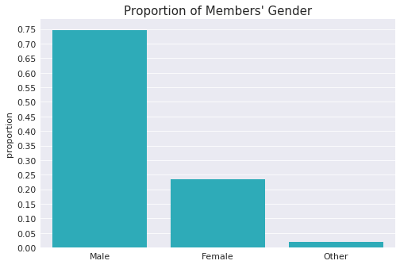

```python
# Creating a bar chat to determine the proportion of the gender among users
plt.figure(figsize=(8,18));

plt.subplot(3,1,1);
tick_props, tick_names, var_sum = prop_(df_copy.member_gender)
sns.countplot(data = df_copy, x = 'member_gender', order= ['Male', 'Female', 'Other'], color = base_colour)
plt.xticks(fontsize=11);
plt.yticks(tick_props * var_sum, tick_names, fontsize=11)
plt.ylabel('proportion',fontsize=11);
plt.xlabel(' ');
plt.title('Proportion of Members\' Gender', fontsize=15);
```

> The proportion of the male gender is higher than the female gender

### Q2: Whats the proportion of user type among the users?

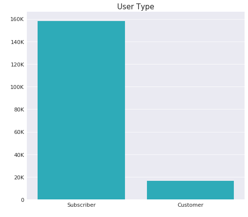

```python
# Plotting a bar chart that displays the proportion of user type among users

plt.figure(figsize=(8,24));
plt.subplot(3,1,2);
sns.countplot(data = df_copy, x = 'user_type', order = ['Subscriber', 'Customer'],color = base_colour)
plt.xticks(fontsize=11);
plt.yticks(np.arange(0,160000+10000,20000), ['0','20K','40K', '60K','80K','100K', '120K', '140K', '160K'],fontsize=11)
plt.ylabel(' ',fontsize=11);
plt.xlabel(' ');
plt.title('User Type', fontsize=15);
```

> The subscriber user type is relatively higher than the customer user type

### Q3: What's the bike sharing behaviour among the users?

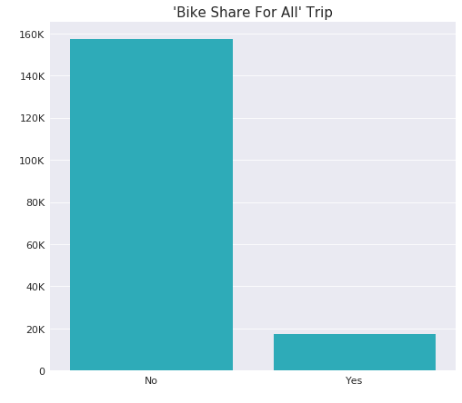

```python
plt.figure(figsize=(8,24));
plt.subplot(3,1,3);
sns.countplot(data = df_copy, x = 'bike_share_for_all_trip', color = base_colour)
plt.xticks(fontsize=11);
plt.yticks(np.arange(0,160000+10000,20000), ['0','20K','40K', '60K','80K','100K', '120K', '140K', '160K'],fontsize=11)
plt.ylabel(' ',fontsize=11);
plt.xlabel(' ');
plt.title('\'Bike Share For All\' Trip', fontsize=15);
```

### Q4: How is the age of the users distributed in the dataset?

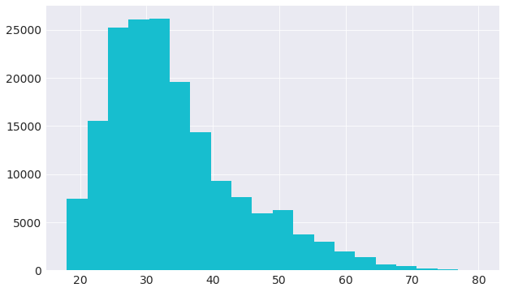

```python
# Plotting an histogram to see how the age of the users distributed in the dataset?

plt.figure(figsize=(10,6))
plt.hist(df_copy.member_age, color = base_colour, bins = 20);
plt.yticks(fontsize=14)
plt.xticks(fontsize=14);
```

> The age distribution is skewed to the right, it contains some outliers. I will use a box plot to have a better view of the age distribution

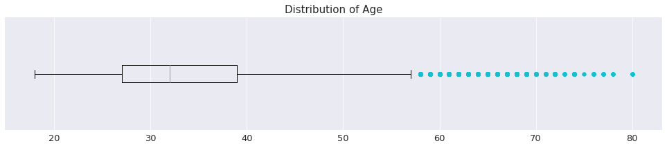

```python
# Plotting a box plot to see the age distribution

plt.figure(figsize=(17,3))
dots = dict(markerfacecolor=base_colour, marker='o')
plt.boxplot(df_copy.member_age, vert=False, flierprops = dots);
plt.yticks([],[]);
plt.xticks(fontsize=13)
plt.title('Distribution of Age', fontsize=15);
```

> From the box plot, it is clear that there are outliers in the age, It is rare that bike riders are above 80 years, I will need to drop the ages that are above 80 from the dataset.

```python
# Dropping other values under 1938.0 i.e users aged above 80

df_copy = df_copy[df_copy['member_birth_year'] > 1938.0]
```

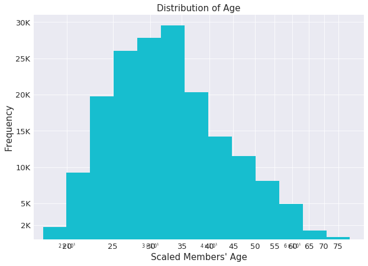

```python
# Re-plotting the histogram for age distribution

plt.figure(figsize=(10,7))
plt.title('Distribution of Age', fontsize=15);

# Get log value of maximum age
log_max = np.log10(df_copy.member_age.max())
bins=10**np.arange(1,log_max+0.2,0.05)

plt.hist(df_copy.member_age, color = base_colour, bins = bins);
plt.xscale('log')
plt.xticks(np.arange(20,80,5),np.arange(20,80,5), fontsize=13);
plt.xlim(17,85);
plt.xlabel('Scaled Members\' Age', fontsize=15);
plt.ylabel('Frequency', fontsize = 15);
plt.yticks([2000, 5000, 10000,15000,20000,25000,30000],['2K', '5K','10K','15K', '20K', '25K', '30K'], fontsize=13);
```

> Most of the users are youths with age bracket 25 to 35. I will place the age in age groups i.e. bins so I can check the proportion of age groups

```python
# Grouping the age into age brackets

bins= [10,20,30,40,50,60,70,80]
labels = ['10-20','20-30','30-40','40-50','50-60', '60-70','70-80']
df_copy['member_age_group'] = pd.cut(df_copy['member_age'], bins=bins, labels=labels, right=False)
```

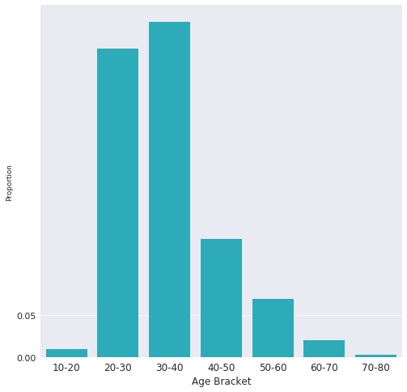

```python
# Plotting a bar chart for the age groups

plt.figure(figsize=(8,8))

tick_props, tick_names, var_sum = prop_(df_copy.member_age_group)
sns.countplot(data=df_copy, x ='member_age_group', color=base_colour);
plt.ylabel('Proportion')
plt.xlabel('Age Bracket', fontsize=12)
plt.yticks(tick_props * var_sum, tick_names, fontsize=11);
plt.xticks(fontsize=12);
```

> From the bar chart above, it is clear that the age group (20-30) and (30-40) are most of the users

### Q5: At what hour do users mostly start their trip?

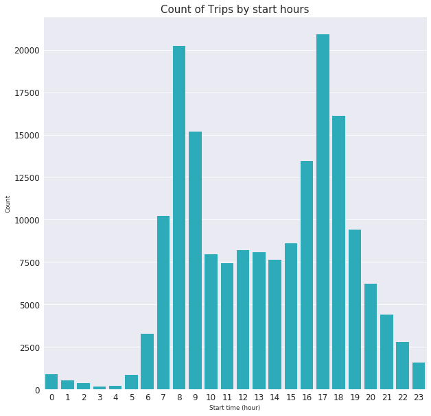

```python
# Plotting a bar chart to see what hour the users mostly start their trip

plt.figure(figsize = [10,10])
plt.title('Count of Trips by start hours', fontsize=15)
plt.plot(2,1,1)
sns.countplot(data = df_copy, x = 'start_time_hour', color=base_colour);
plt.xlabel('Start time (hour)');
plt.ylabel('Count');
plt.xticks(fontsize=12);
plt.yticks(fontsize=12);
```

### Q6: At what hour do users mostly end their trip?

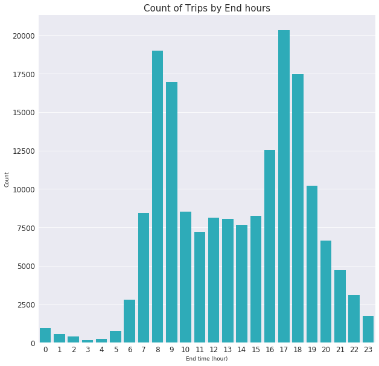

```python
# Plotting a bar chart to see what hour the users mostly start their trip

plt.figure(figsize = [10,10])
plt.title('Count of Trips by End hours', fontsize=15)
plt.plot(2,1,2)
sns.countplot(data = df_copy, x = 'end_time_hour', color=base_colour);
plt.xlabel('End time (hour)');
plt.ylabel('Count');
plt.xticks(fontsize=12);
plt.yticks(fontsize=12);
```

### Q7:Which of the days do users use bikes the most?

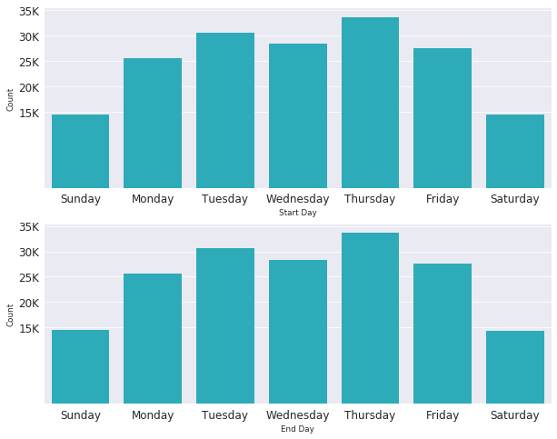

```python
# Plotting 2 bar charts to see which of the days do users use bikes the most
plt.figure(figsize = [10,8])

# For the top plot
plt.subplot(2,1,1)
sns.countplot(data = df_copy, x = 'start_day', color = base_colour)
plt.yticks([15000,20000,25000,30000,35000],['15K', '20K', '25K', '30K','35K']);
plt.xlabel('Start Day');
plt.ylabel('Count');
plt.xticks(fontsize=12);
plt.yticks(fontsize=12);

# For the bottom plot
plt.subplot(2,1,2)
sns.countplot(data = df_copy, x = 'end_day', color = base_colour)
plt.yticks([15000,20000,25000,30000,35000],['15K', '20K', '25K', '30K','35K']);
plt.xlabel('End Day');
plt.ylabel('Count');
plt.xticks(fontsize=12);
plt.yticks(fontsize=12);
```

### Q8: Which of the month do users use bikes the most?

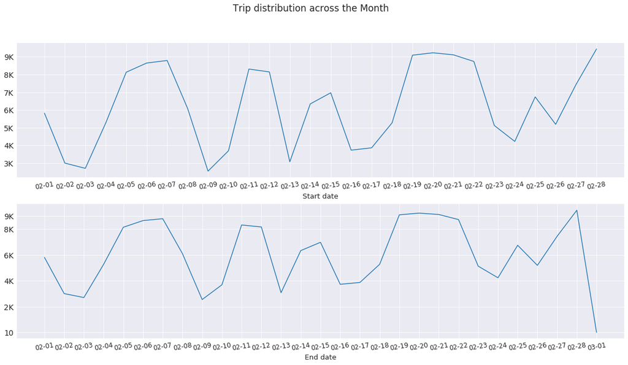

```python
# Plotting a line chart to determine the month which users mostly use bike
plt.figure(figsize=[20,10])
plt.suptitle('Trip distribution across the Month', fontsize=17);

# For top plot
plt.subplot(2,1,1)
freq = df_copy.start_time_month_date.value_counts().sort_index()
plt.plot(freq.index, freq)
plt.yticks([3000,4000,5000,6000,7000,8000,9000],['3K', '4K','5K','6K','7K', '8K','9K'], fontsize=14)
plt.xticks(rotation=10, fontsize=12);
plt.xlabel('Start date', fontsize=13)

# For bottom plot
plt.subplot(2,1,2)
freq = df_copy.end_time_month_date.value_counts().sort_index()
plt.plot(freq.index, freq)
plt.yticks([10,2000,4000,6000,8000,9000],['10','2K', '4K','6K', '8K', '9K'], fontsize=14)
plt.xticks(rotation=10, fontsize=12);
plt.xlabel('End date', fontsize=13);
```

> The line chart is confirming that users rarely rent/return bikes on weekends, but there's an exception for Wednesday, February 13 and February 24.

### Q8: How long do users go for their trips?

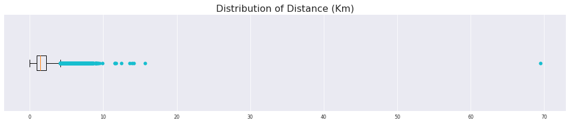

```python
# Plotting a box plot that displays how long do users go for their trips?

plt.figure(figsize=(17,3))
dots = dict(markerfacecolor=base_colour, marker='o')
plt.boxplot(df_copy.station_distance_km, vert=False, flierprops = dots);
plt.yticks([],[]);
plt.title('Distribution of Distance (Km)', fontsize=16);
```

> There's one outlier in the disance covered. I want to drop it from the dataset.

```python
# Craeting a new dataframe that doesn't contain the outlier

df_copy_normal_dist = df_copy[df_copy.station_distance_km < 60]
```

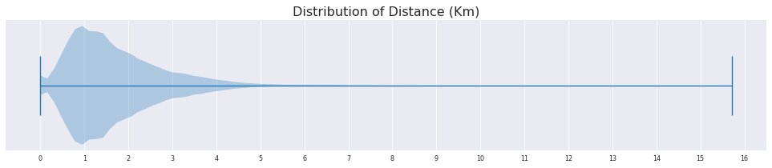

```python
# Plotting a violinplot for distance distribution

plt.figure(figsize=(17,3))
dots = dict(markerfacecolor=base_colour, marker='o')
plt.violinplot(df_copy_normal_dist.station_distance_km, vert=False);
plt.yticks([],[]);
plt.xticks(np.arange(0,17,1), np.arange(0,17,1))
plt.title('Distribution of Distance (Km)', fontsize=16);
```

> From the above plot, most users take trips of about 1 kilometer

### Q9: What stations are used most?

```python
# Filtering top 10 used stations for start and end trips
top_start_vc = df_copy.start_station_name.value_counts().head(10)
end_start_vc = df_copy.end_station_name.value_counts().head(10)

# Creating a  dataframe of most used stations
top_start = df_copy[df_copy['start_station_name'].isin(top_start_vc.index)]
top_end = df_copy[df_copy['end_station_name'].isin(end_start_vc.index)]
```

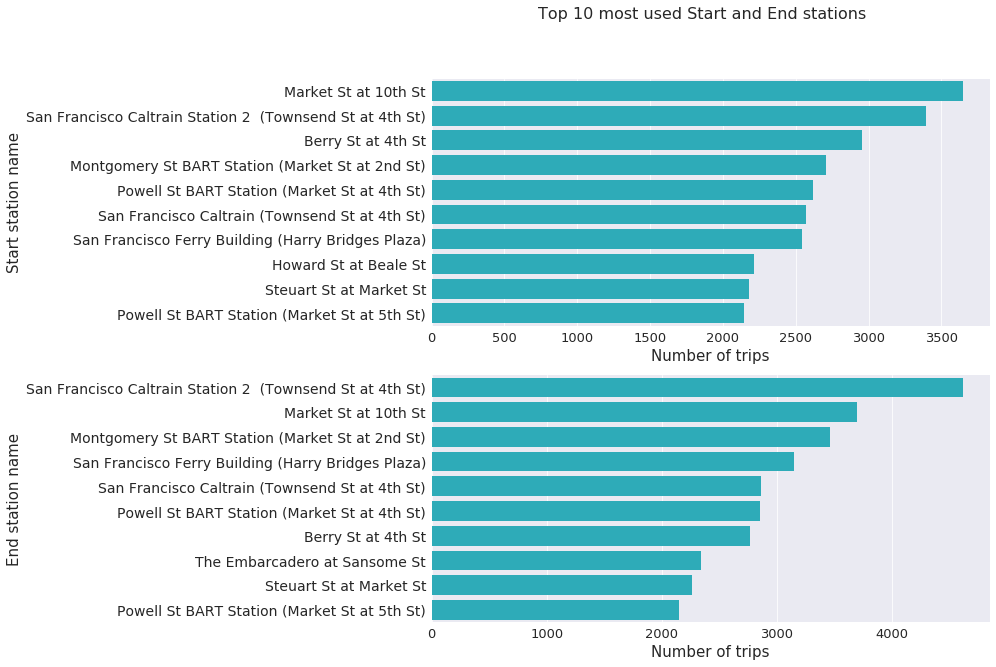

```python
# Creating bar charts to display the stations are used most
plt.figure(figsize=(10,10))
plt.suptitle('Top 10 most used Start and End stations', fontsize=16 );

# For plot on top
plt.subplot(2,1,1)
sns.countplot(data=top_start, y='start_station_name', color=base_colour, order= top_start_vc.index);
plt.ylabel('Start station name', fontsize=15)
plt.xlabel('Number of trips', fontsize=15)
plt.xticks(fontsize=13)
plt.yticks(fontsize=14)

# For plot at the bottom
plt.subplot(2,1,2)
sns.countplot(data=top_end, y='end_station_name', color=base_colour, order= end_start_vc.index);
plt.ylabel('End station name', fontsize=15)
plt.xlabel('Number of trips', fontsize=15);
plt.yticks(fontsize=14)
plt.xticks(fontsize=13);
```

> From the plot above, most of the stations are located around Market St. This may suggests that Market Street is a place full of activities.

## Bivariate Exploration

> I am done with my univarate exploration,I will move to the bivarate exploratin

### Q10: How often do users take trips in the month?

```python
# Grouping the data to user type by month

user_type_by_month = df_copy.groupby(['start_time_month_date','user_type']).size().reset_index()
```

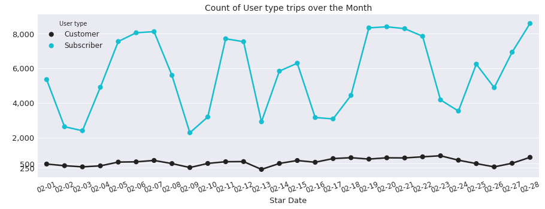

```python
# Plotting a line chart to display how often do users take trips in the month

plt.figure(figsize=(15,5))
sns.pointplot(data = user_type_by_month, x='start_time_month_date', y=0, hue='user_type', color=base_colour);
plt.yticks([250, 500, 2000,4000,6000,8000],['250', '500','2,000', '4,000', '6,000', '8,000'], fontsize=13);
plt.ylabel(' ');
plt.xticks(rotation=20,fontsize=11.5);
plt.xlabel('Star Date', fontsize=13)
plt.legend(title='User type',fontsize=12, loc=2);
plt.title('Count of User type trips over the Month', fontsize=14);
```

> From the above plot, Customers took bikes fairly everyday. On the day of the first flood, February 13, the customer trend had it's lowest record. The amount of subscribers took a sharp increase towards the end of the month, but this can be because the month started on a Friday, a day before the weekend.

### Q11:What is the average distance taken by each age group?

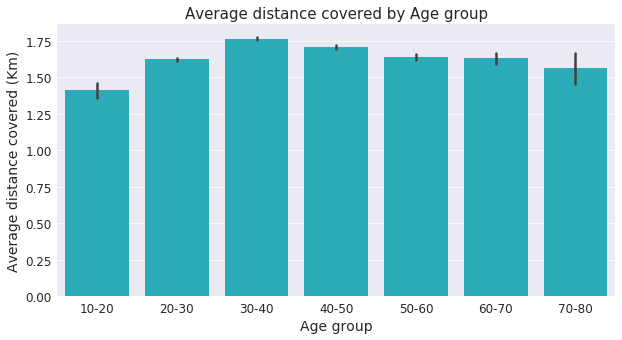

```python
# Plotting a bar chart that displays the average distance taken by age group?

plt.figure(figsize=(10,5))
sns.barplot(data = df_copy, x=df_copy.member_age_group, y=df_copy.station_distance_km,color=base_colour);
plt.title('Average distance covered by Age group', fontsize=15);
plt.xlabel('Age group', fontsize=14);
plt.ylabel('Average distance covered (Km)', fontsize=14);
plt.yticks(fontsize=12);
plt.xticks(fontsize=12);
```

> The average distance taken by each age group has been displayed in the above chart

### Q12: What is the average distance taken by User type?

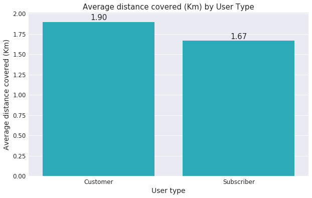

```python
# Plotting a bar chart that displays the average distance taken by User type
plt.figure(figsize=(10,6))


# Using the dataset without the outlier
p = sns.barplot(data = df_copy_normal_dist, x=df_copy_normal_dist.user_type, y=df_copy_normal_dist.station_distance_km,
                color=base_colour, errwidth=0);
plt.title('Average distance covered (Km) by User Type', fontsize=15);
plt.xlabel('User type', fontsize=14);
plt.ylabel('Average distance covered (Km)', fontsize=14);
plt.yticks(fontsize=12);
plt.xticks(fontsize=12);

# For annotation
for bar in p.patches:
    p.annotate(format(bar.get_height(), '.2f'),
                   (bar.get_x() + bar.get_width() / 2,
                    bar.get_height()), ha='center', va='center',
                   size=15, xytext=(0, 8),
                   textcoords='offset points')
```

> The users cover roughly equal distance averagely with less than 0.5 Kilometers for difference. When I was making charts for univariate exploration, there seem to be something interesting about User types and if bike trips are shared. I want to find out more.

```python
# Creating a new datafrme of user type and trip share type
trip_type_df = df_copy.groupby(['bike_share_for_all_trip','user_type']).size().reset_index()
```

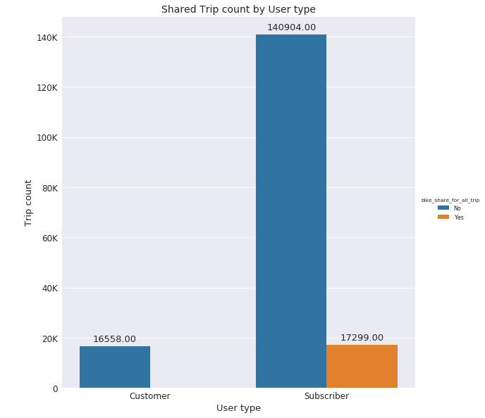

```python
g = sns.factorplot(data=trip_type_df, kind="bar", x="user_type", y=0, hue="bike_share_for_all_trip",
                size=8,legend='auto', legend_out=True)
#g.legend.set_title("")
plt.xticks(fontsize=12)
plt.yticks(np.arange(0,160000,20000),['0','20K', '40K', '60K', '80K', '100K', '120K', '140K'], fontsize=12)
plt.xlabel('User type', fontsize = 13)
plt.ylabel("Trip count", fontsize=13)
plt.title('Shared Trip count by User type', fontsize=14)
# For annotation
for ax in g.axes.ravel():
  for p in ax.patches:
    ax.annotate(format(p.get_height(), '.2f'), (p.get_x() + p.get_width() / 2., p.get_height()),
                ha = 'center', va = 'center', xytext = (0, 10), textcoords = 'offset points', fontsize=13)
```

> The above chart shows that all customers did not share their bike trips, While almost similar population of the customers that are subcribers shared their trips.

## Multivariate Exploration

> I am done with the bivarate exploration, I will move to the multivaraite exploration

### Q13 :What's the trip distance by age group and User type?

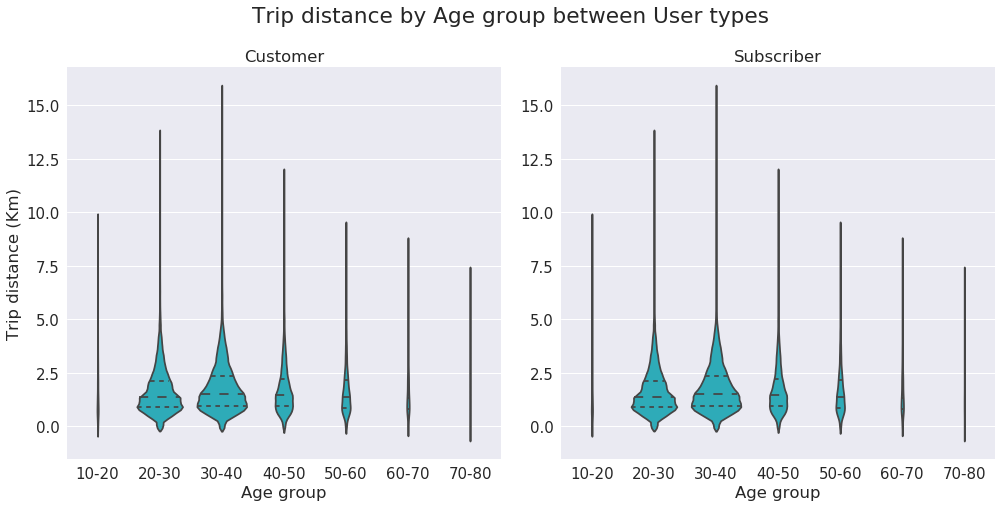

```python
# Plotting a violin plot to display the distance by age group and User type?

sns.set(font_scale=1.5)
g=sns.FacetGrid(data = df_copy_normal_dist, col = 'user_type',
                size = 7)
g.map(sns.violinplot, x=df_copy_normal_dist.member_age_group, y=df_copy_normal_dist.station_distance_km,
            color=base_colour, inner ='quartile', scale='count');
g.set_axis_labels("Age group", "Trip distance (Km)")
g.set_titles('{col_name}');
g.fig.subplots_adjust(top=0.859)
g.fig.suptitle('Trip distance by Age group between User types');
```

> Across the User types, the age groups travel fairly the same distance for trips, with age brackets 0-40 having more users and longer trips.

### Q14: What's the average duration and distance of trips by Gender, User type and Age group?

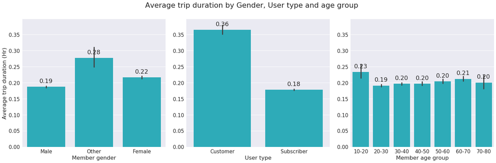

```python
# Plotting bar charts that displays the average trip duration by Gender, User type and Age group

g = sns.PairGrid(df_copy, y_vars="duration_hour",
                 x_vars=["member_gender", "user_type", "member_age_group"], size = 7)
g.map(sns.barplot, color=base_colour)
g.fig.suptitle('Average trip duration by Gender, User type and age group')
g.fig.subplots_adjust(top=0.88)
g.axes[0,0].yaxis.set_label_text('Average trip duration (Hr)')
g.axes[0,0].xaxis.set_label_text('Member gender')
g.axes[0,1].xaxis.set_label_text('User type')
g.axes[0,2].xaxis.set_label_text('Member age group')

# For annotations
for ax in g.axes.ravel():
  for p in ax.patches:
    ax.annotate(format(p.get_height(), '.2f'), (p.get_x() + p.get_width() / 2., p.get_height()),
                ha = 'center', va = 'center', xytext = (0, 17), textcoords = 'offset points')
```

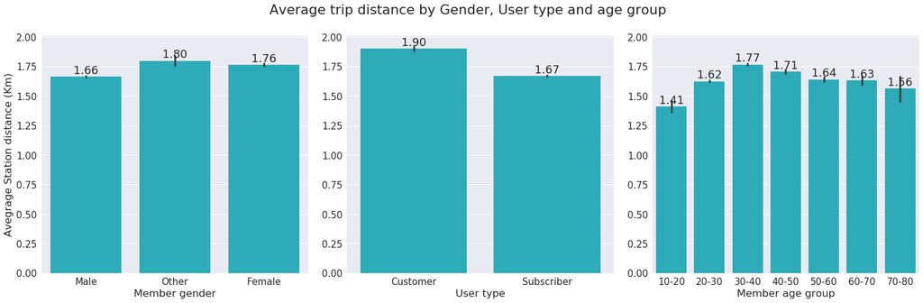

```python
# Plotting bar charts that displays the average trip distance by Gender, User type and Age group

g = sns.PairGrid(df_copy_normal_dist, y_vars="station_distance_km",
                 x_vars=["member_gender", "user_type", "member_age_group"],
                 size=7)

g.map(sns.barplot, color=base_colour);
g.fig.suptitle('Average trip distance by Gender, User type and age group')
g.fig.subplots_adjust(top=0.88)
g.axes[0,0].yaxis.set_label_text('Avegrage Station distance (Km)')
g.axes[0,0].xaxis.set_label_text('Member gender')
g.axes[0,1].xaxis.set_label_text('User type')
g.axes[0,2].xaxis.set_label_text('Member age group')

# For annotations
for ax in g.axes.ravel():
  for p in ax.patches:
    ax.annotate(format(p.get_height(), '.2f'), (p.get_x() + p.get_width() / 2., p.get_height()),
                ha = 'center', va = 'center', xytext = (0, 10), textcoords = 'offset points')
```

> The members with their gender as 'other' take the longes trips with respect to time and distance. Also, Customers take longer trips than Subscribers.

## Conclusions

```python
# Saving the cleaned data to a csv file

df_copy.to_csv('cleaned_bike_data.csv',index=False)
```